# BIOSTAT 620 HW 1

Author

Kyoka Ono

## BIOSTAT 620 HW1

### Question 1 (20 points)

Given the formulated question from the assignment description, you will now conduct ED Checklist items 1-5.

```r
library(tidyverse)
library(dplyr)
library(lubridate)
library(leaflet)
library(kableExtra)
library(maps)
```

First, download 2005 and 2025 PM2.5 data for all sites in Michigan from the EPA Air Quality Data website, then read the data into R.

```r
mi_05 <- read.csv("/Users/kyokaono/Desktop/MI_05.csv")
```

```r
mi_25 <- read.csv("/Users/kyokaono/Desktop/MI_25.csv")
```

For each of the two datasets, check the dimensions, headers, footers, variable names and variable types.

#### 2005 Data Outline

```r
dim(mi_05)
```

```
[1] 5280   22
```

```r
head(mi_05)
```

```
        Date Source   Site.ID POC Daily.Mean.PM2.5.Concentration    Units
1 01/01/2005    AQS 260050003   1                            9.3 ug/m3 LC
2 01/02/2005    AQS 260050003   1                            7.0 ug/m3 LC
3 01/03/2005    AQS 260050003   1                           15.7 ug/m3 LC
4 01/04/2005    AQS 260050003   1                           13.4 ug/m3 LC
5 01/05/2005    AQS 260050003   1                            5.3 ug/m3 LC
6 01/06/2005    AQS 260050003   1                            4.0 ug/m3 LC
  Daily.AQI.Value       Local.Site.Name Daily.Obs.Count Percent.Complete
1              51 966 32nd St (Holland)               1              100
2              39 966 32nd St (Holland)               1              100
3              63 966 32nd St (Holland)               1              100
4              59 966 32nd St (Holland)               1              100
5              29 966 32nd St (Holland)               1              100
6              22 966 32nd St (Holland)               1              100
  AQS.Parameter.Code AQS.Parameter.Description Method.Code
```

[output cut: 27 more lines]

```r
tail(mi_05)
```

```
           Date Source   Site.ID POC Daily.Mean.PM2.5.Concentration    Units
5275 09/01/2005    AQS 261639901   1                           12.8 ug/m3 LC
5276 09/07/2005    AQS 261639901   1                           30.4 ug/m3 LC
5277 09/13/2005    AQS 261639901   1                           46.5 ug/m3 LC
5278 09/25/2005    AQS 261639901   1                           24.4 ug/m3 LC
5279 10/01/2005    AQS 261639901   1                           24.0 ug/m3 LC
5280 10/07/2005    AQS 261639901   1                            2.9 ug/m3 LC
     Daily.AQI.Value Local.Site.Name Daily.Obs.Count Percent.Complete
5275              58                               1              100
5276              91                               1              100
5277             128                               1              100
5278              80                               1              100
5279              79                               1              100
5280              16                               1              100
     AQS.Parameter.Code              AQS.Parameter.Description Method.Code
```

[output cut: 27 more lines]

```r
colnames(mi_05)
```

```
 [1] "Date"                           "Source"
 [3] "Site.ID"                        "POC"
 [5] "Daily.Mean.PM2.5.Concentration" "Units"
 [7] "Daily.AQI.Value"                "Local.Site.Name"
 [9] "Daily.Obs.Count"                "Percent.Complete"
[11] "AQS.Parameter.Code"             "AQS.Parameter.Description"
[13] "Method.Code"                    "Method.Description"
[15] "CBSA.Code"                      "CBSA.Name"
[17] "State.FIPS.Code"                "State"
[19] "County.FIPS.Code"               "County"
[21] "Site.Latitude"                  "Site.Longitude"
```

```r
str(mi_05)
```

```
'data.frame':   5280 obs. of  22 variables:
 $ Date                          : chr  "01/01/2005" "01/02/2005" "01/03/2005" "01/04/2005" ...
 $ Source                        : chr  "AQS" "AQS" "AQS" "AQS" ...
 $ Site.ID                       : int  260050003 260050003 260050003 260050003 260050003 260050003 260050003 260050003 260050003 260050003 ...
 $ POC                           : int  1 1 1 1 1 1 1 1 1 1 ...
 $ Daily.Mean.PM2.5.Concentration: num  9.3 7 15.7 13.4 5.3 4 12.6 29 15.5 13.2 ...
 $ Units                         : chr  "ug/m3 LC" "ug/m3 LC" "ug/m3 LC" "ug/m3 LC" ...
 $ Daily.AQI.Value               : int  51 39 63 59 29 22 58 88 63 59 ...
 $ Local.Site.Name               : chr  "966 32nd St (Holland)" "966 32nd St (Holland)" "966 32nd St (Holland)" "966 32nd St (Holland)" ...
 $ Daily.Obs.Count               : int  1 1 1 1 1 1 1 1 1 1 ...
 $ Percent.Complete              : num  100 100 100 100 100 100 100 100 100 100 ...
 $ AQS.Parameter.Code            : int  88101 88101 88101 88101 88101 88101 88101 88101 88101 88101 ...
 $ AQS.Parameter.Description     : chr  "PM2.5 - Local Conditions" "PM2.5 - Local Conditions" "PM2.5 - Local Conditions" "PM2.5 - Local Conditions" ...
 $ Method.Code                   : int  118 118 118 118 118 118 118 118 118 118 ...
 $ Method.Description            : chr  "R & P Model 2025 PM2.5 Sequential w/WINS" "R & P Model 2025 PM2.5 Sequential w/WINS" "R & P Model 2025 PM2.5 Sequential w/WINS" "R & P Model 2025 PM2.5 Sequential w/WINS" ...
 $ CBSA.Code                     : int  26090 26090 26090 26090 26090 26090 26090 26090 26090 26090 ...
 $ CBSA.Name                     : chr  "Holland, MI" "Holland, MI" "Holland, MI" "Holland, MI" ...
 $ State.FIPS.Code               : int  26 26 26 26 26 26 26 26 26 26 ...
 $ State                         : chr  "Michigan" "Michigan" "Michigan" "Michigan" ...
 $ County.FIPS.Code              : int  5 5 5 5 5 5 5 5 5 5 ...
 $ County                        : chr  "Allegan" "Allegan" "Allegan" "Allegan" ...
 $ Site.Latitude                 : num  42.8 42.8 42.8 42.8 42.8 ...
 $ Site.Longitude                : num  -86.1 -86.1 -86.1 -86.1 -86.1 ...
```

#### 2025 Data Outline

```r
dim(mi_25)
```

```
[1] 9934   22
```

```r
head(mi_25)
```

```
        Date Source   Site.ID POC Daily.Mean.PM2.5.Concentration    Units
1 01/01/2025    AQS 260050003   1                            3.7 ug/m3 LC
2 01/02/2025    AQS 260050003   1                            4.5 ug/m3 LC
3 01/03/2025    AQS 260050003   1                            3.8 ug/m3 LC
4 01/04/2025    AQS 260050003   1                            3.3 ug/m3 LC
5 01/05/2025    AQS 260050003   1                            4.6 ug/m3 LC
6 01/06/2025    AQS 260050003   1                            3.3 ug/m3 LC
  Daily.AQI.Value       Local.Site.Name Daily.Obs.Count Percent.Complete
1              21 966 32nd St (Holland)               1              100
2              25 966 32nd St (Holland)               1              100
3              21 966 32nd St (Holland)               1              100
4              18 966 32nd St (Holland)               1              100
5              26 966 32nd St (Holland)               1              100
6              18 966 32nd St (Holland)               1              100
  AQS.Parameter.Code AQS.Parameter.Description Method.Code
```

[output cut: 20 more lines]

```r
tail(mi_25)
```

```
           Date Source   Site.ID POC Daily.Mean.PM2.5.Concentration    Units
9929 12/26/2025 AirNow 261630100   1                            5.2 ug/m3 LC
9930 12/27/2025 AirNow 261630100   1                            5.4 ug/m3 LC
9931 12/28/2025 AirNow 261630100   1                           10.7 ug/m3 LC
9932 12/29/2025 AirNow 261630100   1                            2.4 ug/m3 LC
9933 12/30/2025 AirNow 261630100   1                            3.4 ug/m3 LC
9934 12/31/2025 AirNow 261630100   1                            6.7 ug/m3 LC
     Daily.AQI.Value      Local.Site.Name Daily.Obs.Count Percent.Complete
9929              29 Military Park (GHIB)               1              100
9930              30 Military Park (GHIB)               1              100
9931              54 Military Park (GHIB)               1              100
9932              13 Military Park (GHIB)               1              100
9933              19 Military Park (GHIB)               1              100
9934              37 Military Park (GHIB)               1              100
     AQS.Parameter.Code AQS.Parameter.Description Method.Code
```

[output cut: 20 more lines]

```r
colnames(mi_25)
```

```
 [1] "Date"                           "Source"
 [3] "Site.ID"                        "POC"
 [5] "Daily.Mean.PM2.5.Concentration" "Units"
 [7] "Daily.AQI.Value"                "Local.Site.Name"
 [9] "Daily.Obs.Count"                "Percent.Complete"
[11] "AQS.Parameter.Code"             "AQS.Parameter.Description"
[13] "Method.Code"                    "Method.Description"
[15] "CBSA.Code"                      "CBSA.Name"
[17] "State.FIPS.Code"                "State"
[19] "County.FIPS.Code"               "County"
[21] "Site.Latitude"                  "Site.Longitude"
```

```r
str(mi_25)
```

```
'data.frame':   9934 obs. of  22 variables:
 $ Date                          : chr  "01/01/2025" "01/02/2025" "01/03/2025" "01/04/2025" ...
 $ Source                        : chr  "AQS" "AQS" "AQS" "AQS" ...
 $ Site.ID                       : int  260050003 260050003 260050003 260050003 260050003 260050003 260050003 260050003 260050003 260050003 ...
 $ POC                           : int  1 1 1 1 1 1 1 1 1 1 ...
 $ Daily.Mean.PM2.5.Concentration: num  3.7 4.5 3.8 3.3 4.6 3.3 3 2.8 7.7 17.7 ...
 $ Units                         : chr  "ug/m3 LC" "ug/m3 LC" "ug/m3 LC" "ug/m3 LC" ...
 $ Daily.AQI.Value               : int  21 25 21 18 26 18 17 16 43 67 ...
 $ Local.Site.Name               : chr  "966 32nd St (Holland)" "966 32nd St (Holland)" "966 32nd St (Holland)" "966 32nd St (Holland)" ...
 $ Daily.Obs.Count               : int  1 1 1 1 1 1 1 1 1 1 ...
 $ Percent.Complete              : num  100 100 100 100 100 100 100 100 100 100 ...
 $ AQS.Parameter.Code            : int  88101 88101 88101 88101 88101 88101 88101 88101 88101 88101 ...
 $ AQS.Parameter.Description     : chr  "PM2.5 - Local Conditions" "PM2.5 - Local Conditions" "PM2.5 - Local Conditions" "PM2.5 - Local Conditions" ...
 $ Method.Code                   : int  170 170 170 170 170 170 170 170 170 170 ...
 $ Method.Description            : chr  "Met One BAM-1020 Mass Monitor w/VSCC" "Met One BAM-1020 Mass Monitor w/VSCC" "Met One BAM-1020 Mass Monitor w/VSCC" "Met One BAM-1020 Mass Monitor w/VSCC" ...
 $ CBSA.Code                     : int  26090 26090 26090 26090 26090 26090 26090 26090 26090 26090 ...
 $ CBSA.Name                     : chr  "Holland, MI" "Holland, MI" "Holland, MI" "Holland, MI" ...
 $ State.FIPS.Code               : int  26 26 26 26 26 26 26 26 26 26 ...
 $ State                         : chr  "Michigan" "Michigan" "Michigan" "Michigan" ...
 $ County.FIPS.Code              : int  5 5 5 5 5 5 5 5 5 5 ...
 $ County                        : chr  "Allegan" "Allegan" "Allegan" "Allegan" ...
 $ Site.Latitude                 : num  42.8 42.8 42.8 42.8 42.8 ...
 $ Site.Longitude                : num  -86.1 -86.1 -86.1 -86.1 -86.1 ...
```

Check the distribution of the key variable we are analyzing (PM2.5). Write up a summary of all of your findings.

#### Key Variables & Summary & Distributions:

- Date
- Daily.Mean.PM2.5.Concentration
- Daily.AQI.Value
- County
- Local.Site.Name
- Site.Latitude, Site.Longitude

```r
summary(mi_05$Daily.Mean.PM2.5.Concentration)
```

```
   Min. 1st Qu.  Median    Mean 3rd Qu.    Max.
   0.00    6.20   11.00   13.77   18.70   81.60
```

```r
summary(mi_05$Daily.AQI.Value)
```

```
   Min. 1st Qu.  Median    Mean 3rd Qu.    Max.
   0.00   34.00   55.00   54.15   69.00  169.00
```

```r
mi_05[which(max(mi_05$Daily.Mean.PM2.5.Concentration) == mi_05$Daily.Mean.PM2.5.Concentration),]
```

```
           Date Source   Site.ID POC Daily.Mean.PM2.5.Concentration    Units
3672 02/05/2005    AQS 261630001   1                           81.6 ug/m3 LC
     Daily.AQI.Value Local.Site.Name Daily.Obs.Count Percent.Complete
3672             169      Allen Park               1              100
     AQS.Parameter.Code AQS.Parameter.Description Method.Code
3672              88101  PM2.5 - Local Conditions         118
                           Method.Description CBSA.Code
3672 R & P Model 2025 PM2.5 Sequential w/WINS     19820
                       CBSA.Name State.FIPS.Code    State County.FIPS.Code
3672 Detroit-Warren-Dearborn, MI              26 Michigan              163
     County Site.Latitude Site.Longitude
3672  Wayne      42.22861      -83.20833
```

```r
head(sort(table(mi_05$County), decreasing = TRUE))
```

```
    Wayne      Kent   Allegan  Chippewa Washtenaw Kalamazoo
     1643       475       421       378       343       228
```

```r
kable(head(sort(table(mi_05$Local.Site.Name), decreasing = TRUE))) # missing data detected
```

| Var1 | Freq |
| --- | --- |
| Allen Park | 523 |
| GR-MONROE | 475 |
| 966 32nd St (Holland) | 421 |
| DET-LINWOOD | 338 |
|  | 274 |
| NORTH OF EASTERDAY AVE LK SUPERIOR STATE UNIV | 244 |

```r
summary(mi_25$Daily.Mean.PM2.5.Concentration)
```

```
   Min. 1st Qu.  Median    Mean 3rd Qu.    Max.
  0.000   4.000   6.300   8.304  10.100 116.000
```

```r
summary(mi_25$Daily.AQI.Value)
```

```
   Min. 1st Qu.  Median    Mean 3rd Qu.    Max.
   0.00   22.00   35.00   38.71   53.00  193.00
```

```r
mi_25[which(max(mi_25$Daily.Mean.PM2.5.Concentration) == mi_25$Daily.Mean.PM2.5.Concentration),]
```

```
           Date Source   Site.ID POC Daily.Mean.PM2.5.Concentration    Units
3802 07/30/2025    AQS 261030013   1                            116 ug/m3 LC
     Daily.AQI.Value                                       Local.Site.Name
3802             193 Negaunee Township, Off Pump House Road, Pump House #2
     Daily.Obs.Count Percent.Complete AQS.Parameter.Code
3802               1              100              88101
     AQS.Parameter.Description Method.Code
3802  PM2.5 - Local Conditions         636
                                            Method.Description CBSA.Code
3802 Teledyne T640 at 5.0 LPM w/Network Data Alignment enabled     32100
         CBSA.Name State.FIPS.Code    State County.FIPS.Code    County
3802 Marquette, MI              26 Michigan              103 Marquette
     Site.Latitude Site.Longitude
3802      46.51812      -87.52156
```

```r
head(sort(table(mi_25$County), decreasing = TRUE))
```

```
    Wayne      Kent Washtenaw Kalamazoo       Bay   Lenawee
     3549       796       634       399       370       365
```

```r
kable(head(sort(table(mi_25$Local.Site.Name), decreasing = TRUE)))
```

| Var1 | Freq |
| --- | --- |
| YPSILANTI TOWNER ST, SOUTH; | 634 |
| PROPERTY OWNED BY DEARBORN PUBLIC SCHOOLS | 465 |
| DETROIT-SOUTHWEST (DET-SW) | 461 |
| Allen Park | 446 |
| GR-MONROE | 436 |
| Kalamazoo Fairgrounds | 399 |

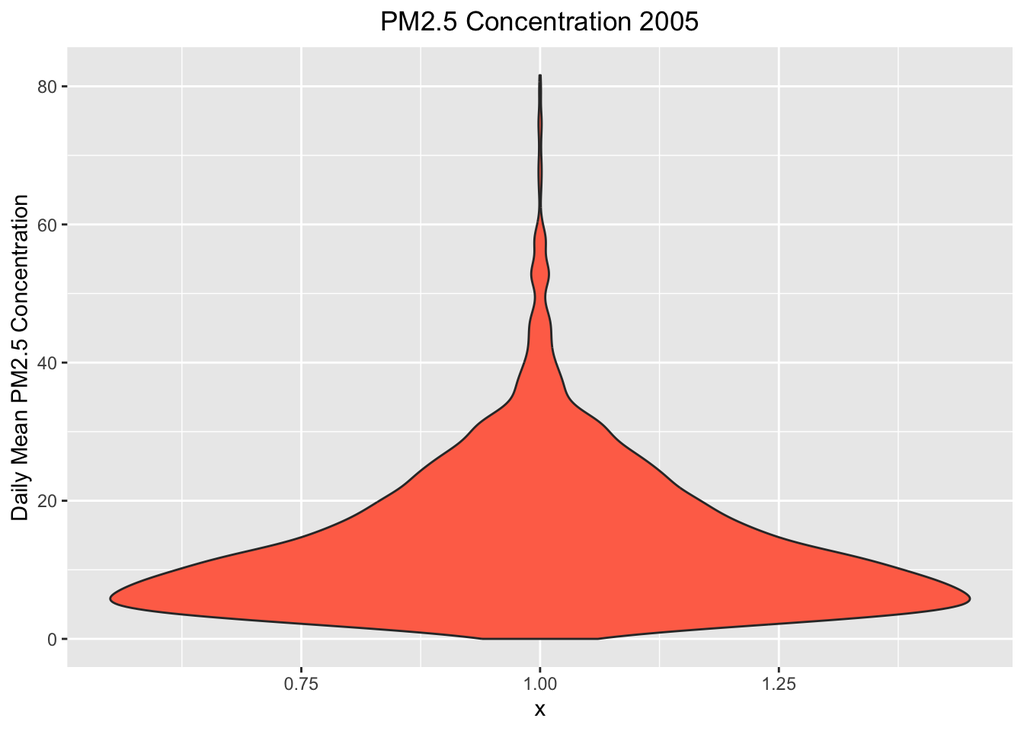

```r
ggplot(data = mi_05) +
  geom_violin(mapping = aes(x = 1, y = Daily.Mean.PM2.5.Concentration), fill ="coral1") +
  labs(title = "PM2.5 Concentration 2005") +
  labs(y = "Daily Mean PM2.5 Concentration") +
  theme(plot.title = element_text(hjust = 0.5))
```

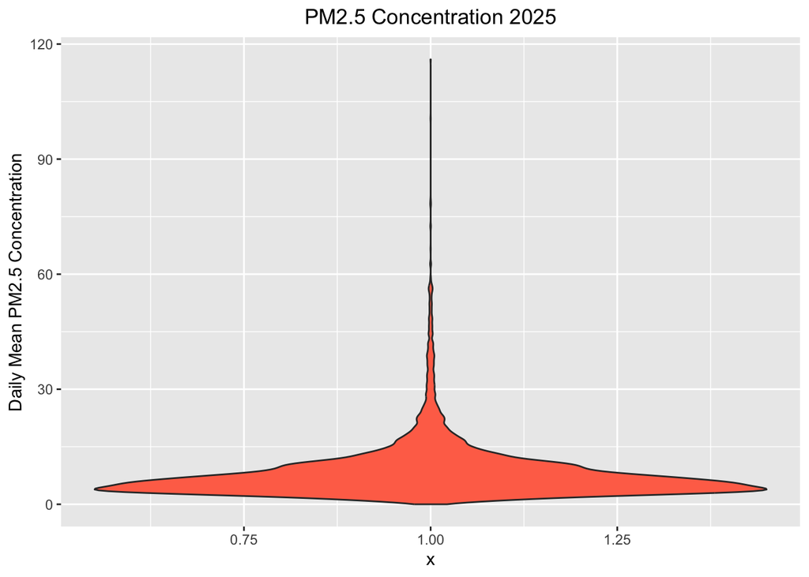

```r
ggplot(data = mi_25) +
  geom_violin(mapping = aes(x = 1, y = Daily.Mean.PM2.5.Concentration), fill = "coral1") +
  labs(title = "PM2.5 Concentration 2025") +
  labs(y = "Daily Mean PM2.5 Concentration") +
  theme(plot.title = element_text(hjust = 0.5))
```

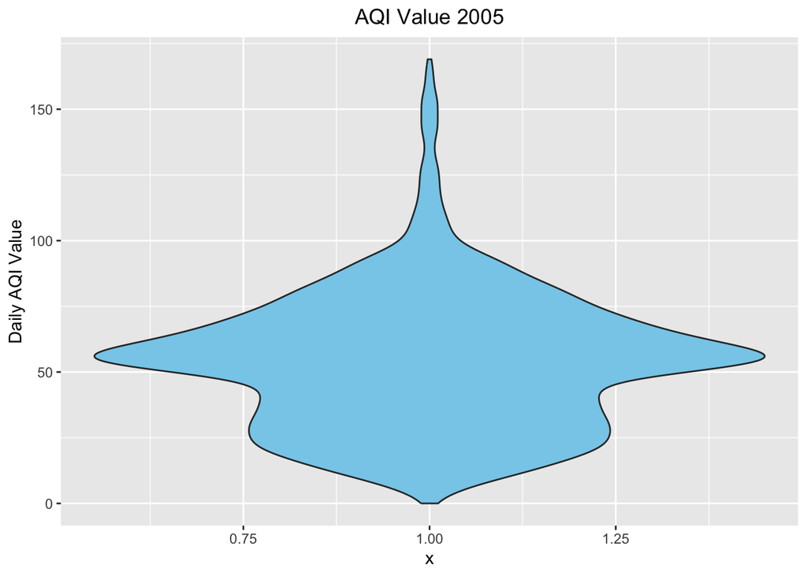

```r
ggplot(data = mi_05) +
  geom_violin(mapping = aes(x = 1, y = Daily.AQI.Value), fill = "skyblue") +
  labs(title = "AQI Value 2005") +
  labs(y = "Daily AQI Value") +
  theme(plot.title = element_text(hjust = 0.5))
```

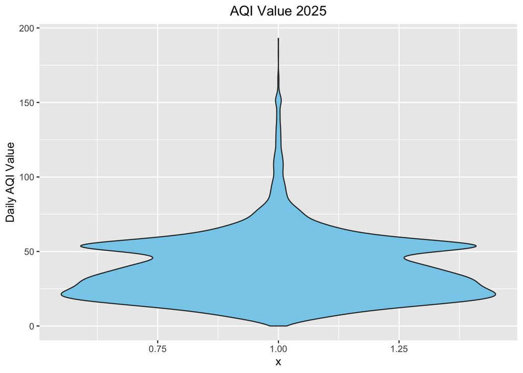

```r
ggplot(data = mi_25) +
  geom_violin(mapping = aes(x = 1, y = Daily.AQI.Value), fill = "skyblue") +
  labs(title = "AQI Value 2025") +
  labs(y = "Daily AQI Value") +
  theme(plot.title = element_text(hjust = 0.5))
```

The overall daily mean PM2.5 concentration has decreased from 2005 to 2025. Additionally, daily Air Quality Index (AQI) value has also decreased from 2005 to 2025 overall (can be concluded from the violin plots). The maximum PM2.5 and AQI values increased from 2005 to 2025; however, they were detected at two different counties and local sites. Additionally, investigated counties were similar in 2005 and 2025, but not quite for local sites. Missing data were detected in some columns as well.

### Question 2 (10 pts)

Combine two years of data into one data frame. Use the Date variable to create a new column for year, which will serve as identifier. Change the names of the key variables so that they are easier to refer to in your code.

```r
mi_05_25 <- rbind(mi_05, mi_25)
```

```r
mi_05_25$Date <- mdy(mi_05_25$Date)
```

```r
mi_05_25 <- mi_05_25 %>% mutate(year = factor(year(mi_05_25$Date)))
```

### Question 3 (20pts)

Create a basic map (or maps) in either leaflet or ggplot showing the locations of the monitoring sites, using different colors for each year. Summarize the spatial distribution of the sites. Does this distribution change from 2005 to 2025?

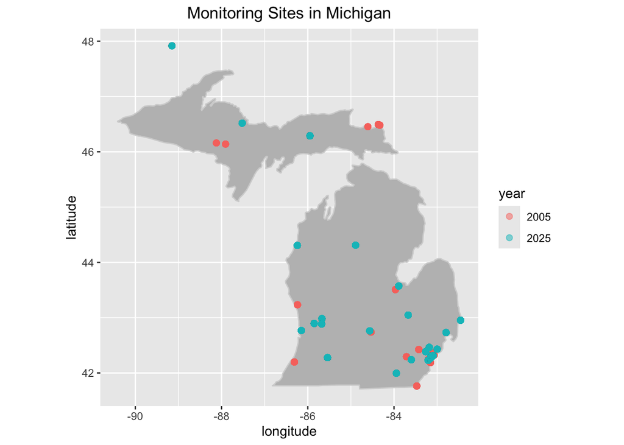

```r
state_data <- map_data("state")
michigan_data <- state_data[state_data$region == "michigan",]

ggplot(michigan_data, aes(x = long, y = lat)) +
  geom_map(aes(map_id = region), map = michigan_data, col = "lightgrey", fill = "gray") +
  geom_jitter(
    data = mi_05_25,
    mapping = aes(x = Site.Longitude, y = Site.Latitude, color = year),
    inherit.aes = FALSE, alpha = .5, cex = 2) +
  labs(title = "Monitoring Sites in Michigan") +
  theme(plot.title = element_text(hjust = 0.5),
        aspect.ratio = 1) +
  labs(x = "longitude", y = "latitude")
```

The distribution of monitoring sites between 2005 and 2025 seem to slightly differ. Additionally, there are more population in the bottom peninsula, which is possibly a reason why there are more sites investigated there in 2025.

### Question 4 (20 points)

Check for any data issues such as missing or implausible values of PM2.5 in the combined dataset.

```r
na_vec <- c()
empty_vec <- c()
for (i in 1:ncol(mi_05_25)){
  na_vec[i] <- c(sum(is.na(mi_05_25[,i])))
  empty_vec[i] <- c(sum(mi_05_25[,i] == ""))
}
na_vec
```

```
 [1]    0    0    0    0    0    0    0    0    0    0    0    0 2543    0  854
[16]    0    0    0    0    0    0    0    0
```

```r
empty_vec
```

```
 [1]   NA    0    0    0    0    0    0  633    0    0    0    0   NA 2543   NA
[16]  854    0    0    0    0    0    0    0
```

```r
sum(is.na(mi_05_25[,13]))
```

```
[1] 2543
```

```r
sum(is.na(mi_05_25[,15]))
```

```
[1] 854
```

```r
sum(mi_05_25[,8] == "")
```

```
[1] 633
```

There are 2543 missing values in “Method.Code” column and 854 missing variables in “CBSA.Code” column. Additionally, there are 633 missing variables in “Local.Site.Name”.

No negative values

```r
which(mi_05_25$Daily.Mean.PM2.5.Concentration < 0)
```

```
integer(0)
```

Although some sites detected PM2.5 of 0, it is very rare.

```r
mi_05_25[which(mi_05_25$Daily.Mean.PM2.5.Concentration == 0),]
```

```
            Date Source   Site.ID POC Daily.Mean.PM2.5.Concentration    Units
823   2005-01-22    AQS 260330901   5                              0 ug/m3 LC
850   2005-04-28    AQS 260330901   5                              0 ug/m3 LC
9365  2025-05-20    AQS 261130001   1                              0 ug/m3 LC
13033 2025-08-12    AQS 261630033   2                              0 ug/m3 LC
      Daily.AQI.Value                               Local.Site.Name
823                 0 NORTH OF EASTERDAY AVE LK SUPERIOR STATE UNIV
850                 0 NORTH OF EASTERDAY AVE LK SUPERIOR STATE UNIV
9365                0           LOCATED ABOUT 1/4 MILE WEST OF SITE
13033               0     PROPERTY OWNED BY DEARBORN PUBLIC SCHOOLS
      Daily.Obs.Count Percent.Complete AQS.Parameter.Code
823                 1              100              88502
850                 1              100              88502
9365                1              100              88101
13033               1              100              88101
```

[output cut: 20 more lines]

Let’s look more closely at the methods used for data collection. Look at the distribution of the method code variable. Examine the two most common method codes in the EPA PM2.5 Codetable, and describe your findings.

```r
method_code <- mi_05_25$Method.Code
# 2005 Method Code
head(sort(table(method_code[mi_05_25$year == 2005]), decreasing = TRUE),2)
```

```
 118  810
4355  607
```

```r
# 2025 Method Code
head(sort(table(method_code[mi_05_25$year == 2025]), decreasing = TRUE),2)
```

```
 636  170
3941 1741
```

The method 118 and 810 were used the most in 2005, and the method 636 and 170 were used the most in 2025. 118 and 810 are both Intermittent recording style, whereas 636 and 170 are both Continuous recording style, which may indicate that the method from 2025 is more accurate.

Calculate the proportion of missing values and method code for each year and report any temporal patterns you see in these observations. Why might these temporal patterns matter?

```r
# 2005 Proportion
proportion_data_05 <- mi_05_25 %>%
  group_by(Method.Code) %>%
  filter(year == 2005) %>%
  summarize(method_prop_05 = n() / nrow(mi_05))
head(proportion_data_05)
```

```
# A tibble: 4 × 2
  Method.Code method_prop_05
        <int>          <dbl>
1         118        0.825
2         707        0.0519
3         781        0.00833
4         810        0.115
```

```r
# 2025 Proportion
proportion_data_25 <- mi_05_25 %>%
  group_by(Method.Code) %>%
  filter(year == 2025) %>%
  summarize(method_prop_25 = n() / nrow(mi_25))
head(proportion_data_25)
```

```
# A tibble: 6 × 2
  Method.Code method_prop_25
        <int>          <dbl>
1         145        0.0326
2         170        0.175
3         636        0.397
4         638        0.134
5         707        0.00493
6          NA        0.256
```

### Question 5 (30 points)

Explore the main question of interest at three different levels of spatial resolution. Create data visualizations (e.g. boxplots, histograms, line plots, violin plots) **and** summary statistics that best suit each level of the analysis. Be sure to write up explanations of what you observe at each level. For levels 2 and 3, include at least one spatial plot.

Level 1: State. Examine the primary question for the entire state.

The summary statistics and violin plots are already compared in Question 1.

Level 2: County. Examine the primary question for every county in Michigan.

```r
# 2005
pm_ave_data_05 <- mi_05_25 %>%
  filter(year == 2005) %>% group_by(County) %>%
  summarize(pm_ave_05 = mean(Daily.Mean.PM2.5.Concentration))
head(pm_ave_data_05,10)
```

```
# A tibble: 10 × 2
   County    pm_ave_05
   <chr>         <dbl>
 1 Allegan       12.7
 2 Bay           12.4
 3 Berrien       13.1
 4 Chippewa       8.25
 5 Dickinson      7.32
 6 Genesee       12.9
 7 Ingham        13.5
 8 Iron           4.40
 9 Kalamazoo     14.7
10 Kent          14.3
```

```r
# 2025
pm_ave_data_25 <- mi_05_25 %>%
  filter(year == 2025) %>% group_by(County) %>%
  summarize(pm_ave_25 = mean(Daily.Mean.PM2.5.Concentration))
head(pm_ave_data_25,10)
```

```
# A tibble: 10 × 2
   County    pm_ave_25
   <chr>         <dbl>
 1 Allegan        8.95
 2 Bay            8.54
 3 Genesee        6.54
 4 Ingham         7.87
 5 Kalamazoo      9.07
 6 Kent           9.81
 7 Keweenaw       1.84
 8 Lenawee        7.97
 9 Macomb         7.88
10 Manistee       6.69
```

The majority of the county have their average PM2.5 decreased from 2005 to 2025.

Level 3: City. Restrict the data to sites in Wayne county and examine the primary question for every site.

```r
wayne_data_05 <- mi_05_25 %>%
  filter(County == "Wayne", year == 2005, Local.Site.Name != "")

wayne_data_25 <- mi_05_25 %>%
  filter(County == "Wayne", year == 2025, !(Local.Site.Name == ""))
```

https://ggplot2.tidyverse.org/reference/map_data.html (reference for map_data(“county”))

```r
county_data <- map_data("county")
michigan_data <- county_data[county_data$region == "michigan",]
wayne_data <- michigan_data[michigan_data$subregion == "wayne",]
```

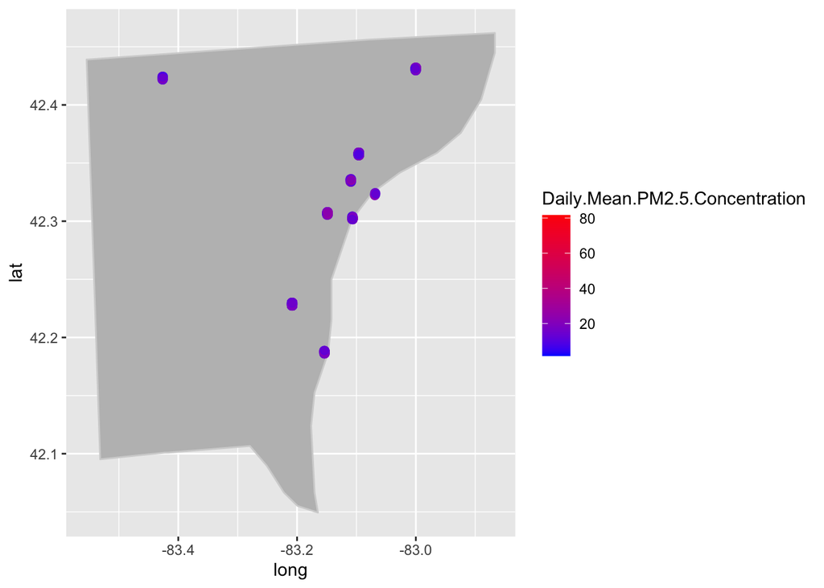

```r
# 2005
ggplot(wayne_data, aes(x = long, y = lat)) +
  geom_map(aes(map_id = region), map = wayne_data, col = "lightgrey", fill = "gray") +
  geom_jitter(
    data = wayne_data_05,
    mapping = aes(x = Site.Longitude, y = Site.Latitude, color = Daily.Mean.PM2.5.Concentration),
    alpha = .5, cex = 2) +
  scale_color_gradient(low = "blue", high = "red")
```

```r
  labs(title = "Wayne County PM2.5 Concentration 2005") +
  theme(plot.title = element_text(hjust = 0.5),
        aspect.ratio = 1) +
  labs(x = "longitude", y = "latitude")
```

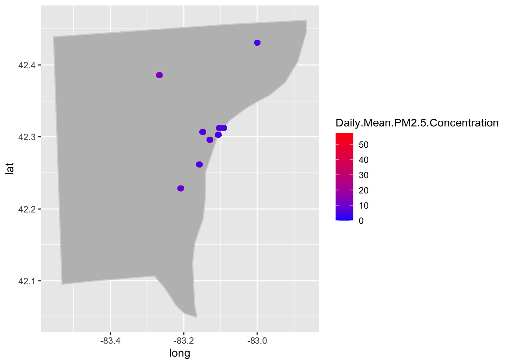

```r
# 2025
ggplot(wayne_data, aes(x = long, y = lat)) +
  geom_map(aes(map_id = region), map = wayne_data, col = "lightgrey", fill = "gray") +
  geom_jitter(
    data = wayne_data_25,
    mapping = aes(x = Site.Longitude, y = Site.Latitude, color = Daily.Mean.PM2.5.Concentration),
    alpha = .5, cex = 2) +
  scale_color_gradient(low = "blue", high = "red")
```

```r
  labs(title = "Wayne County PM2.5 Concentration 2005") +
  theme(plot.title = element_text(hjust = 0.5),
        aspect.ratio = 1) +
  labs(x = "longitude", y = "latitude")
```

PM2.5 seem to fall within the range of 15-30 in 2005, and 5-15 in 2025. Therefore, it can be concluded that PM2.5 has decreased in Wayne county.